# Day 6: Causal inference on networks

- Show All Code
- Hide All Code
- View Source

Advanced Network Analysis · ICPSR

Author

Shahryar Minhas

Published

July 22, 2026

**NoteHow to use this document**

Open the Day 6 teaching deck.

Everything in here runs. There is no separate script; this *is* the script, with the reasoning left in. Read it top to bottom in class; re-run it top to bottom afterwards and you will get the same numbers: the fits are seeded at `6886` or cached, and the quick simulation chunks draw from the seeded stream *in document order* (so a lone simulation chunk re-run out of order can wobble; the document as a whole cannot).

The three cached fits comprise two `ame` MCMC runs (the $R=2$ main fit and the $R=0$ comparison, a few minutes each on a laptop) and one `dcr` decomposition (~1s, cached only so the document reproduces byte-for-byte). They are wrapped in `cache_fit()`, which stores them in `cache/`. The first person to run a chunk pays for the fit, everyone after loads it in milliseconds. Delete `cache/` to force honest refits, knowing that a cold rebuild costs a few minutes, almost all of it the two `ame` chains. Everything else today runs live in seconds.

Two of today’s packages come from GitHub, the rest from CRAN:

```r
install.packages(c("netify", "igraph", "digest", "multiwayvcov", "remotes"))
remotes::install_github("s7minhas/lame")    # The AME workhorse from Days 2-3
remotes::install_github("jscarlson/dcr")    # Dyadic cluster-robust SEs
```

(`multiwayvcov` is the engine `dcr()` actually calls, but `dcr`’s DESCRIPTION forgets to declare it, so installing `dcr` alone leaves you one package short and the first `dcr()` call on a fresh laptop dies with “there is no package called ‘multiwayvcov’”. The line above closes that trap; the toolbox aside in Section 8 shows `dcr_sandwich()`, the same estimator built on packages `dcr` *does* declare.)

**Where this day sits on the map.** Every day so far answered *dyadic observations are not independent; where do you put the dependence?* By changing the **model**: through latent effects in the conditional mean (Days 2-3), into the probability of the graph itself (Day 4), across time (Day 5). Today is a genuinely new cell: leave the model alone and interrogate the **design**: what would it take for any of those coefficients to be read as a *causal* effect, and what can you do when the answer is “more than my data can deliver”?

**NoteToday’s path**

| Segment |
| --- |
| The committee question: a new cell on the map |
| Interference: one unit’s treatment lands in another’s outcome |
| Exposure mappings: the formal fix (literacy, not lab) |
| What randomization buys |
| The observational frontier: the honest sentence |
| The runnable tool: fix the standard errors instead |
| The rebel cooperation network + the model everyone fits |
| DCR, live: asymptotic and small-sample reference distributions |
| The census: why you should care |
| The other answer on the same underlying network |
| Watch them disagree |
| The open seam: what a controlled head-to-head still needs |
| What you can honestly claim |
| Your turn (exercises) |
| Close: which model when? (Day 7) |
| Reading |

If you are short on time, segments 2, 8, and 11 are the ones you cannot skip: the problem made vivid, the tool you can actually run, and the honest disagreement between the two answers this course has taught you.

# 1 The committee question

Here is an email I get every year, in some form:

> “I presented my network results and my committee asked whether the effect is causal. What do I say?”

This day is the long version of the answer. The short version has three parts, and I will say it now so you can hear the whole arc before we build it:

1. **On a network, “causal” is harder than it is anywhere else**, not just because of confounding, which you know about, but because of *interference*: one unit’s treatment can land in another unit’s outcome, and that breaks the assumption underneath almost every causal estimator you have ever used. We will make that failure vivid in code early in the document.
2. **Methods exist for the randomized world, and a frontier exists for the observational world**, and for most of the data this room works with, the honest sentence is *“we cannot defend the assumptions,”* which is a different and better sentence than *“no method exists.”*
3. **There is one thing you can run today**, on the regression you already have: dyadic cluster-robust standard errors. It does not make anything causal. It makes your *uncertainty* honest, and there is a published census showing exactly how dishonest the field’s uncertainty has been.

## 1.1 Political Science Questions That Create Interference

Interference is common in political science because political treatments travel through relationships:

- A campaign contacts one voter, who discusses the message with friends or family.
- A civic-information program reaches one village, while information and participation spill across kinship or market ties.
- A sanction targets one state, changing incentives for its allies and trade partners.
- A peacebuilding intervention reaches one armed group, while cooperation and rivalry alter outcomes for connected groups.

The first question is not “which network estimator should I run?” It is **which versions of treatment and network exposure define the potential outcomes I want to compare?** The network may change the outcome itself, the uncertainty of an estimator, or both. Those are separate problems.

For any application, write down four objects before estimating:

1. The treatment assignment mechanism.
2. The network used to define exposure.
3. The exposure mapping that compresses neighbors’ assignments into a condition.
4. The direct or spillover contrast among potential outcomes.

If the design gives some units zero probability of a required exposure condition, that contrast is not identified for those units by weighting harder.

## 1.2 The Applied Method Compass

Not everything today is a new outcome model. That distinction is part of the applied lesson.

[output not shown]

A human conclusion must say which operation occurred. Did we redefine exposure, change the conditional mean, or keep the mean and change only uncertainty? Calling all three a “network adjustment” hides the actual inferential move.

Before any of that, remember where Day 3 left you. Across four models, SRM, blockmodels, distance, and AME, two days of latent-variable machinery bought calibration, fit, and real structure. It did not buy **identification**: the license to read the number you estimated as the causal effect you wanted. This figure closed the latent-geometry day, and it is the hinge into today. A five-day-old memory deserves a two-sentence re-set: the grey line is the truth we built into the simulation; the “oracle” is a model that cheats and observes the hidden trait $W$ directly; and the question is what happens to everyone else’s $\hat\beta$ when $W$, an unobserved trait that drives ties, *also* moves with the covariate $X$:

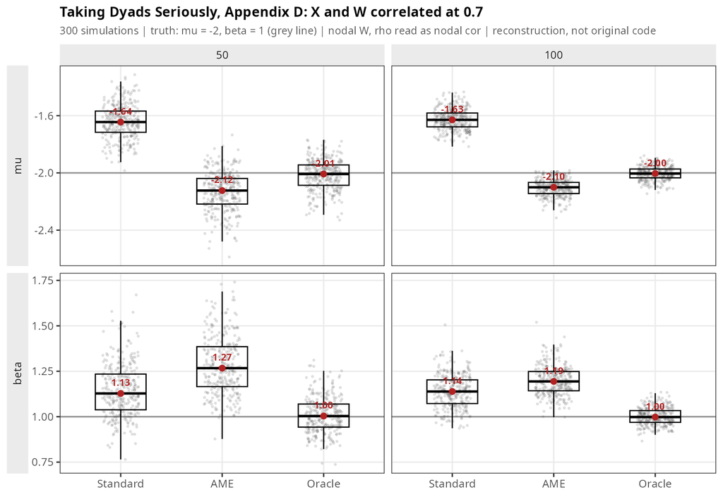

Reconstruction of Appendix D of Minhas et al. (2022), from Day 3. Truth is the grey line ($\mu=-2$, $\beta=1$). When the unobserved homophily term W is *correlated* with the covariate X (here at 0.7), the AME estimate of $\beta$ drifts off the truth just like the standard model; only the oracle, which observes W, recovers it.

The latent factors soak up the part of the omitted structure that is **orthogonal** to your covariate, unrelated to it, and that is what they are built to do. They cannot disentangle the part that is **collinear** with it, moving in step with it, and that is exactly the part that biases $\beta$. The same is true of the ERGM’s dependence terms and the SAOM’s rate function: modeling dependence well is not the same operation as identifying an effect.

**ImportantThe frame for the whole day**

Everything this course has estimated so far is a **dependence-adjusted association**. That is a real and valuable thing: better calibrated and less confounded by network structure than a naive regression, but it is not a causal effect. Today is about what separates the two, and about which parts of that gap you can close with design, which parts with assumptions you must defend out loud, and which parts you should concede in print.

No new homework today; HW 4 was due yesterday. Today’s exercises are the kind you run on your own project.

# 2 Interference: one unit’s treatment lands in another’s outcome

Start abstract, because this problem is not about countries or rebels or students; it is about **units, treatments, and outcomes**, whatever those are in your discipline.

The workhorse assumption of causal inference is that each unit $i$ has two potential outcomes, $Y_i(1)$ and $Y_i(0)$, treated and untreated, and your unit’s outcome depends on *your* treatment only. Rubin called the relevant bundle SUTVA (the “stable unit treatment value assumption”); the part we care about is **no interference between units** (Cox’s phrase): what happens to $j$ cannot depend on what was assigned to $i$.

On a network, that assumption is not a technicality you wave through. It is *the thing you are studying*. Ties exist precisely because units transmit things to each other: information, money, disease, and conflict. If the network means anything at all, interference is real.

Let’s build the smallest world where you can watch it happen. A random undirected network of 60 units, and an outcome with a known truth: your outcome goes up by **2** if *you* are treated, and by **1.5** if *any of your neighbors* is treated.

```r
set.seed(6886)
n <- 60
g <- matrix(rbinom(n * n, 1, 0.08), n, n)   # A random undirected graph
g[lower.tri(g)] <- t(g)[lower.tri(g)]
diag(g) <- 0
deg <- rowSums(g)
c(units = n, mean_degree = round(mean(deg), 1), isolates = sum(deg == 0))
```

```
#>       units mean_degree    isolates
#>        60.0         4.8         0.0
```

```r
outcome <- function(z, eps) {
  exposed <- as.numeric((g %*% z) > 0)   # Do I have >= 1 treated neighbor?
  1 + 2 * z + 1.5 * exposed + eps
}
```

Read that function signature again, because it is the whole point: `outcome(z, eps)` takes the **entire treatment vector**. Unit $j$’s outcome is not $Y_j(z_j)$ anymore; it is $Y_j(\mathbf{z})$, a function of everyone’s assignment. Now watch a SUTVA violation happen to one specific unit:

```r
z   <- rbinom(n, 1, 0.5)   # A randomized experiment
eps <- rnorm(n)
j <- which(z == 0 & as.numeric(g %*% z) == 1)[1]  # A CONTROL unit with
i <- which(g[j, ] == 1 & z == 1)[1]               # Exactly 1 treated nbr, i
z_flip    <- z
z_flip[i] <- 0             # Change i's treatment. Nobody else's. Not j's.
y_before <- outcome(z, eps)
y_after  <- outcome(z_flip, eps)
c(j = j, z_j = z[j], y_j_before = round(y_before[j], 2),
  y_j_after = round(y_after[j], 2))
```

```
#>          j        z_j y_j_before  y_j_after
#>      38.00       0.00       3.36       1.86
```

Unit 38 is a control unit. Its own treatment never changed. Its outcome moved by 1.5: the full spillover effect, because we flipped its *neighbor*. With $n$ units there are $2^n$ treatment vectors, so unit $j$ does not have two potential outcomes; it has up to $2^{60} \approx 1.2 \times 10^{18}$ of them. “The treatment effect for $j$” has stopped being a well-defined phrase.

And here is what that does to the estimator everyone runs first. This *is* a randomized experiment; assignment is a fair coin, no confounding anywhere, so difference-in-means should be golden:

```r
dm <- replicate(1000, {
  z <- rbinom(n, 1, 0.5)
  y <- outcome(z, rnorm(n))
  mean(y[z == 1]) - mean(y[z == 0])
})
all_vs_none <- mean(outcome(rep(1, n), 0)) - mean(outcome(rep(0, n), 0))
c(diff_in_means = round(mean(dm), 2), treat_everyone = all_vs_none)
```

```
#>  diff_in_means treat_everyone
#>           1.99           3.50
```

```r
checkpoint(spillover_seen_by_j = round(y_before[j] - y_after[j], 2),
           diff_in_means = round(mean(dm), 2),
           policy_effect = all_vs_none)
```

```
#> ------------------------------------------------------------------
#> CHECKPOINT: spillover_seen_by_j = 1.5   |   diff_in_means = 1.99   |   policy_effect = 3.5
#> ------------------------------------------------------------------
```

Difference-in-means converges on 1.99: the *direct* effect of your own treatment. But the question a policymaker (or an epidemiologist, or a school principal) usually asks is “what happens if we roll this out to everyone?”, and *that* number is 3.5: direct effect plus spillover. The experiment did not lie, exactly; it silently answered a **different question** than the one asked, and nothing in its output warns you. (And this DGP was kind: spillovers here are additive and symmetric, so difference-in-means at least lands on *something* interpretable. Exercise 2 breaks that kindness and watches it land on a number no substantive question asks for.)

**ImportantInterference does not add noise. It changes the question.**

Under interference, randomization still gives known assignment probabilities. Those probabilities can support unbiased estimators for exposure-specific estimands when the exposure mapping and estimator match the design. A naive difference in means is not automatically unbiased for a direct, spillover, or policy effect. “The effect” splinters into direct effects, spillover effects, and total policy effects, and you have to say which one you want.

# 3 Exposure mappings: the formal fix

So if there are $2^n$ potential outcomes per unit, how does anyone do *anything*? The modern answer, from Aronow & Samii (2017), one of today’s readings, is the **exposure mapping**: a function $f(\mathbf{z}, i)$ that collapses the full treatment vector down to the handful of *conditions* you believe matter for unit $i$. In our simulated world the true mapping is four conditions: (own treatment) $\times$ (any treated neighbor). Under that mapping, each condition has a well-defined average outcome, and contrasts between conditions are well-defined causal estimands:

```r
cond_of <- function(z) {
  exposed <- as.numeric((g %*% z) > 0)
  factor(paste0("z=", z, ", exposed=", exposed),
         levels = c("z=0, exposed=0", "z=1, exposed=0",
                    "z=0, exposed=1", "z=1, exposed=1"))
}
sims <- replicate(500, {
  z <- rbinom(n, 1, 0.5)
  y <- outcome(z, rnorm(n))
  tapply(y, cond_of(z), mean)
})
round(rowMeans(sims, na.rm = TRUE), 2)
```

```
#> z=0, exposed=0 z=1, exposed=0 z=0, exposed=1 z=1, exposed=1
#>           1.07           3.00           2.52           4.50
```

The four cell means land where the truth says they should (1, 3, 2.5, 4.5): a direct effect of 2, a spillover of 1.5, visible separately and in combination. (The two “no treated neighbor” cells wobble the most because a fair coin leaves only two or three units per draw in those rare cells, and that rarity is about to matter.) This is what “estimating causal effects under interference” *means*; you stop asking for “the” effect and estimate condition-vs-condition contrasts.

Two things make this rigorous rather than just a cross-tab, and both are load-bearing:

1. **The exposure mapping is an assumption.** We used the true one because we wrote the simulation. In real work you assert “only first-degree neighbors matter” (or “only the fraction treated matters”) and your estimands are defined *relative to that assertion*. Get it wrong and you are back to bias with cleaner notation.
2. **You must know each unit’s probability of landing in each condition.** Under a known randomization those probabilities are computable (for a fair coin, unit $i$ with degree $d_i$ has $\Pr(\text{control, no treated neighbor}) = 0.5 \times 0.5^{d_i}$), and Aronow & Samii plug them into Horvitz–Thompson estimators: weighted means that divide each unit by its known probability of landing in its condition, no more magic than that, with honest variance bounds. **“Known” is the load-bearing word.** No randomization, no known probabilities, no estimator. This is why today teaches exposure mappings as *literacy*: vocabulary you need to read the literature and to design a study, and not as a lab you can point at observational dyadic data.

**CautionThe software situation, verified so you don’t waste a weekend**

We do not run the Aronow-Samii estimators today, and the reason is worth stating plainly: as of this course’s build (July 2026, R 4.3.3), the R implementations in this space verifiably do not install on our stack. The `interference` package lives only on GitHub; `interferenceCI` and `netchain` have been archived off CRAN; and `inferference` (the Pérez-Heydrich/Hudgens two-stage package) is on CRAN but fails to install because its dependency `spaMM` does not compile. We tried, so you don’t have to.

If your project genuinely has a randomized design with network spillovers: the Horvitz–Thompson machinery is a weighted mean, not black magic (the folded aside below computes one by hand in ten lines), the design probabilities are yours by construction, and this is the moment to involve a statistician rather than trust an unmaintained package.

(We open the next fold live in class rather than skipping past it: it is the first half’s one chance to watch a wrong number get *fixed*: the raw cell contrast misses the truth by nearly a full point, and the reweighting walks it back. If you are reading at home, do not skip it either.)

**NoteHorvitz-Thompson by hand, and why “known probabilities” is not pedantry**

The Horvitz-Thompson estimator works in a transparent sequence:

1. Enumerate or simulate assignments from the known randomization design.
2. Apply the exposure mapping to every assignment.
3. Calculate each unit’s probability $\pi_i(c)$ of landing in exposure condition $c$.
4. Keep the observed outcomes of units who actually landed in $c$.
5. Weight each of those outcomes by $1/\pi_i(c)$ so rare exposure assignments represent the units who could have occupied them.
6. Average over the target population, then subtract condition-specific means to form the declared causal contrast.

The weighting is not a generic cure for confounding. Its justification comes from the known assignment probabilities.

Make the world slightly meaner: let the baseline outcome rise with degree (hubs are simply different: more visible and more resourced), which is true in essentially every real network.

```r
set.seed(6886)
outcome_deg <- function(z, eps) {
  exposed <- as.numeric((g %*% z) > 0)
  1 + 0.4 * deg + 2 * z + 1.5 * exposed + eps  # Baseline rises with degree
}
# Design probabilities, exact under a fair-coin assignment:
p11 <- 0.5 * (1 - 0.5^deg)   # Treated AND >= 1 treated neighbor
p00 <- 0.5 * 0.5^deg         # Control AND no treated neighbor
# HT weights are undefined for isolates: an isolate has p11 = 0, so its
# weight in the treated-and-exposed cell is 0/0 = NaN. This graph has no
# isolates (see the first chunk of the day), but guard anyway; a unit
# with ZERO probability of a condition is a unit the design cannot speak
# about, which is a real design lesson, not a coding nuisance.
keep <- deg > 0
est <- replicate(2000, {
  z  <- rbinom(n, 1, 0.5)
  y  <- outcome_deg(z, rnorm(n))
  ex <- as.numeric((g %*% z) > 0)
  c(cell_means = mean(y[z == 1 & ex == 1]) - mean(y[z == 0 & ex == 0]),
    horvitz_thompson =
      sum((y * (z == 1 & ex == 1) / p11)[keep]) / sum(keep) -
      sum((y * (z == 0 & ex == 0) / p00)[keep]) / sum(keep))
})
truth <- mean(outcome_deg(rep(1, n), 0)) - mean(outcome_deg(rep(0, n), 0))
ht_res <- round(c(truth = truth, rowMeans(est, na.rm = TRUE)), 2)
ht_res
```

```
#>            truth       cell_means horvitz_thompson
#>             3.50             4.53             3.61
```

The raw cell-mean contrast is off by roughly a full point, and the reason is selection *created by the network itself*: high-degree units almost always have a treated neighbor, so the “exposed” cells over-sample hubs and the “unexposed” cells over-sample the periphery. The Horvitz–Thompson estimator reweights each unit by its known design probability and lands close to the truth: 3.61 against a truth of 3.5, where the raw cells gave 4.53. The residual wobble is HT’s well-known price: those $1/p$ weights explode for hubs (the rarest cell probability in this little graph is already $0.001$), which is why Aronow & Samii spend much of the paper on variance bounds. Take away two things: the fix is arithmetic you can do by hand, and it is *only* available because the assignment mechanism, and hence every $\pi_i$, was known. Observational data hands you neither.

# 4 What randomization buys, and what it doesn’t

One slide’s worth, because the design literature is a course of its own. Randomization buys you **no confounding**: treatment is independent of potential outcomes, full stop. It does *not* buy you freedom from interference; our coin-flip experiment above was perfectly randomized and still answered a different question than the policy one.

But if you control the design, you can attack interference *at assignment time*. The leading idea is **graph cluster randomization** (Ugander, Karrer, Backstrom & Kleinberg 2013; Eckles, Karrer & Ugander 2017): cluster the graph, then randomize *clusters* rather than units, so that most units sit in a neighborhood that is uniformly treated or uniformly control, close to the “everyone treated” vs “nobody treated” worlds the policy question actually contrasts.

```r
suppressMessages(library(igraph))
set.seed(6886)
blk   <- rep(1:6, each = 10)                # A network WITH community structure
p_blk <- ifelse(outer(blk, blk, "=="), 0.35, 0.02)
g2 <- matrix(rbinom(n * n, 1, p_blk), n, n)
g2[lower.tri(g2)] <- t(g2)[lower.tri(g2)]
diag(g2) <- 0
ig2  <- graph_from_adjacency_matrix(g2, mode = "undirected")
memb <- membership(cluster_louvain(ig2))    # Day 2 machinery, new job
z_unit <- rbinom(n, 1, 0.5)                 # Design A: Randomize units
z_clus <- sample(rep(0:1, length.out =      # Design B: Randomize clusters,
                       max(memb)))[memb]    #   Balanced across arms
pure <- function(z, gm) {   # Share of units whose whole nbhd matches them
  frac <- as.numeric(gm %*% z) / pmax(rowSums(gm), 1)
  mean((z == 1 & frac == 1) | (z == 0 & frac == 0))
}
c(pure_unit = round(pure(z_unit, g2), 2),
  pure_cluster = round(pure(z_clus, g2), 2))
```

```
#>    pure_unit pure_cluster
#>         0.13         0.45
```

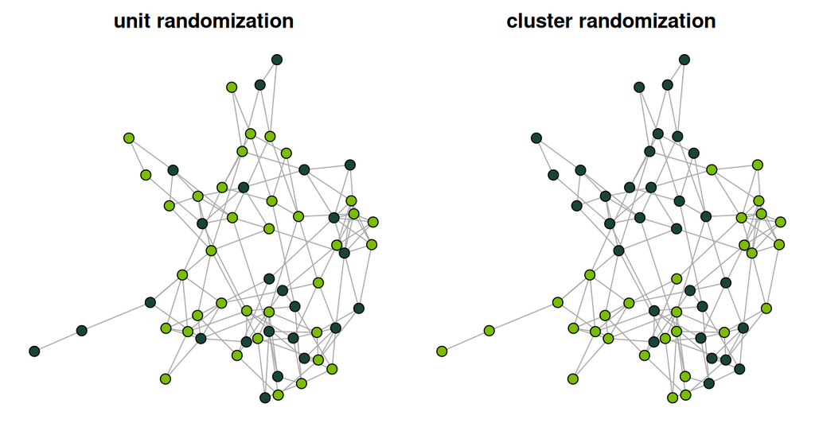

The same network under two designs. Left: unit randomization scatters treatment through every neighborhood, so almost nobody experiences a ‘pure’ condition. Right: cluster randomization gives whole communities a uniform assignment. Color = assigned treatment.

```r
lay <- layout_with_fr(ig2)
par(mfrow = c(1, 2), mar = c(0.5, 0.5, 2, 0.5))
plot(ig2, layout = lay, vertex.size = 6, vertex.label = NA,
     vertex.color = ifelse(z_unit == 1, "#7BBD00", "#18453B"),
     main = "unit randomization")
plot(ig2, layout = lay, vertex.size = 6, vertex.label = NA,
     vertex.color = ifelse(z_clus == 1, "#7BBD00", "#18453B"),
     main = "cluster randomization")
```

Under unit randomization, 13% of units sit in a pure all-treated or all-control neighborhood; under cluster randomization it is 45% in this draw. That is the trade the design makes: much less interference bias, at the price of fewer effective units (you randomized 6 clusters, not 60 people). And that price is not rhetorical: with only 6 clusters we drew a *balanced* assignment above, because a fair coin per cluster puts every cluster in the same arm with probability $2 \times 0.5^{6} = 3.1\%$, which would leave an experiment with no contrast at all. Notice the pleasant echo: the community-detection machinery from Day 2 just became a *causal design tool*. This is what Facebook-scale experiments actually do, and Eckles et al. (2017) show the bias reduction is large even when the clustering is imperfect.

If you remember one sentence from this segment: **randomization plus design choices can handle interference; none of these protections is available to a purely observational study.** That is where most of you live, so the observational frontier comes next.

# 5 The observational frontier: the honest sentence

Can you do causal inference on an observed network, no randomization anywhere? The frontier says: sometimes, under assumptions you must be prepared to defend one by one, out loud.

The foundational warning is Shalizi & Thomas (2011): in observational network data, **homophily and contagion are generically confounded**. Did your friend’s adoption cause yours, or do you both have the same unobserved trait that made you friends in the first place *and* made you both adopt? Without further structure, no amount of data separates these. That is not defeatism; it is the precise statement of what any credible method must overcome, and you already *felt* it on Day 3, where latent homophily was exactly the $W$ that AME could not disentangle from $X$.

Three entries from the current frontier, so you know what exists and what each one charges as its price of admission. And a task while we walk them, zoom very much included: **be the referee of your own project as each one goes by**: your job by the end of the list is to have picked the *one* assumption your own data most clearly fails.

- **Ogburn, Sofrygin, Díaz & van der Laan (2024, *JASA*).** Semiparametric (TMLE) estimation of direct and spillover effects from a *single* observed network. The price: the network is completely and correctly measured, all confounders, including the ones that drive tie formation, are observed, and dependence reaches only as far as the edges you recorded.
- **Egami & Tchetgen Tchetgen (2024, *JRSS-B*).** Peer effects identified despite *unmeasured* network confounding, using double negative controls: an auxiliary outcome and exposure that the causal path cannot touch. The price: you can name a valid negative-control pair in your data and defend it substantively.
- **Hoshino & Yanagi (2024, *JASA*).** Treatment effects with noncompliance and interference of unknown form, instrumental-variables style. One honest flag on where it lives: their leading case is a *randomized encouragement design* with noncompliance; assignment is randomized and instruments the endogenous uptake, so to use it purely observationally you must find an as-if-randomly-assigned instrument. The price: a defensible instrument, in a network setting where exclusion restrictions are even harder to argue than usual.

So, referee: is your trade network “completely and correctly measured”? Is every driver of alliance formation observed? Can you name a negative-control outcome for your conflict spillover story? For most observational dyadic data, certainly for most IR data, the answer is no, and no honest amount of wanting changes it.

(Zoom: type your answer in the chat *now*: the one assumption from that list your own data most clearly fails, and we will discuss what comes in. Everyone fails at least one. The skill being built is knowing *which*, because that is the sentence that goes in your paper.)

**ImportantThe sentence to write in your paper**

**“The methods exist; our data cannot defend their assumptions.”** Never write “causal inference on networks is impossible”; it is false, and a referee who knows this literature will catch it. And do not creep toward causal language your design has not earned. The defensible move is to name the assumption you cannot defend (unmeasured drivers of tie formation, latent homophily, mismeasured edges), cite the method that would need it, and state what you estimate instead: a dependence-adjusted association.

Which raises the practical question this day has been building toward: if you cannot buy identification, what *can* you buy, today, on the regression you already have? Honest uncertainty. That tool exists, it takes four lines, and the rest of today is an honest fight about it.

# 6 The runnable tool: don’t model it, fix the standard errors

Step all the way back to Day 1. The problem this course circles is that dyadic rows are not independent, because one actor sits in $2(n-1)$ of the $n(n-1)$ rows. Days 2 through 5 answered by **modeling** that dependence by giving it a term ($a_i$, $b_j$, $u_i^\top D v_j$, a triangle statistic, a rate function) and reading covariates off the enriched model.

There is a second answer, and it is almost the opposite philosophy: **do not model the dependence at all.** Keep the naive regression, point estimates and all, and change only how you compute the standard errors so they stop pretending that rows sharing an actor are independent. This is the **variance-correction** answer. On Day 1 you saw a four-line preview (clustering on the sender pulled a ~50% false-positive rate most of the way back to 5%); the grown-up version clusters on *both* members of the dyad, was proposed by Fafchamps & Gubert (2007), formalized for regression by Aronow, Samii & Assenova (2015), and is implemented in the `dcr` package.

## 6.1 How Dyadic Cluster-Robust Variance Is Estimated

The DCR calculation leaves the fitted coefficients alone and rebuilds their estimated covariance matrix:

1. Fit the ordinary `lm` or `glm` and retain its coefficient estimate, design matrix, and observation-level score or residual contribution.
2. Identify every pair of dyad rows that shares at least one actor, regardless of whether that actor appears in the same sender or receiver position.
3. Form the covariance “meat” from cross-products of score contributions for those potentially dependent row-pairs.
4. Count self-pairs and row-pairs with multiple shared memberships correctly rather than adding the same covariance contribution twice.
5. Place that dependence-adjusted “meat” between the model’s usual inverse-information “bread” matrices.
6. Apply the documented finite-sample degrees-of-freedom correction when the actor count is small.
7. Recompute standard errors, test statistics, and intervals from the new covariance matrix.

Because $\hat\beta$ is never re-estimated, DCR cannot repair a misspecified conditional mean. It answers whether the original coefficient table looked too certain under a shared-actor dependence structure.

The contrast with everything you have learned this week is sharp:

|  | AME (latent-model answer) | DCR (variance-correction answer) |
| --- | --- | --- |
| What it changes | The whole model: adds $a_i, b_j, u_i^\top D v_j$ | Only $\widehat{\text{Var}}(\hat\beta)$ |
| Point estimates | **Re-estimated**, they move | **Untouched**, identical to the naive fit |
| Interval widths | Can widen **or narrow** | Often **widen**, but not guaranteed$^\dagger$ |
| What you get out | Effects, random effects, latent geometry, prediction | Corrected standard errors, nothing else |

$^\dagger$ the dyadic cluster-robust variance adds estimated cross-dyad covariance terms. Positive member-sharing dependence often makes the corrected interval wider, but neither the sign nor the finite-sample result is guaranteed. Those terms can go the other way, and in a folded aside below you will watch one go the other way on real data). One scale note for the exactness-minded: the AME column above describes the directed model; today’s Gade fit is the symmetric version, $a_i$ and $u_i^\top \Lambda u_j$.

Hold onto the two bold rows. They are the reason the two methods can reach different verdicts on the same coefficient, and the reason one of them can reach verdicts the other structurally *cannot*. And, the robust-inference camp replies before you get too impressed: DCR can also *refuse* verdicts the other cannot refuse. Every AME verdict is contingent on a latent specification being right. DCR avoids that latent specification, but it is still contingent on the regression target, member-sharing dependence structure, and large-cluster approximation.

One more thing, because this is the causal day: **DCR makes nothing causal.** It is in this session because it makes fewer additional dependence-model commitments. State the sandwich estimator’s own assumptions, claim only what the design supports, and above all stop reporting uncertainty you do not have. It is the floor of honest practice, not a ceiling of ambition. This is not design-based causal inference in the Section 3 sense. There is no randomization in DCR and no known assignment probabilities. Carlson et al. call the method what it is, cluster-robust variance estimation, and the estimand is still whatever your (possibly misspecified) regression targets.

# 7 The data, and the model everyone would fit

We run today’s fight on a network where the substance is not trade but **who cooperates with whom among Syrian rebel groups**: the application from Gade, Gabbay, Hafez & Kelly (2019), one of today’s readings. In the abstract: 30 actors, an undirected binary tie, dyadic covariates (ideological distance, power asymmetry, shared location, shared sponsor) and nodal covariates (a group’s average ideology, its size). Ideological homophily is their headline finding: groups that are ideologically close are the ones that cooperate. One flag before we fit anything: their headline lives in models of the *weighted count* of cooperative acts. We binarize the tie for today’s logit-vs-AME comparison, and you will see below that this choice alone is enough to dim the headline star: a robustness lesson we get for free before the corrections even start.

```r
load("data/gadeData.rda")
data$coopActionsBin <- as.numeric(data$coopActions > 0)
gnet <- netify(
  input = data, actor1 = "actor1", actor2 = "actor2",
  symmetric = TRUE, weight = "coopActionsBin",
  nodal_vars = c("averageId_actor1", "size_actor1"),
  dyad_vars  = c("ideol_diff", "powerdiff", "loc", "spons")
)
# The network is undirected, so netify was called symmetric = TRUE. The 870
# rows in `data` are mirror-doubled: each unordered pair appears twice. Count
# the underlying undirected quantities, not the directed rows.
n_act <- length(unique(c(data$actor1, data$actor2)))
c(actors          = n_act,
  undirected_ties = sum(data$coopActionsBin) / 2,   # 870 rows -> 85 real ties
  undirected_dyads = n_act * (n_act - 1) / 2,        # 30 groups -> 435 pairs
  density          = round(mean(data$coopActionsBin), 3))
```

```
#>           actors  undirected_ties undirected_dyads          density
#>           30.000           85.000          435.000            0.195
```

And here is the model everyone in every discipline would have fit before this week: a logit, dyads assumed independent:

```r
d <- data
d$actor1 <- as.character(d$actor1); d$actor2 <- as.character(d$actor2)
naive_fit <- glm(
  coopActionsBin ~ ideol_diff + powerdiff + loc + spons +
    averageId_actor1 + size_actor1,
  data = d, family = binomial
)
round(summary(naive_fit)$coefficients, 3)
```

```
#>                  Estimate Std. Error z value Pr(>|z|)
#> (Intercept)        -4.997      0.733  -6.816    0.000
#> ideol_diff         -0.114      0.086  -1.329    0.184
#> powerdiff          -0.016      0.019  -0.836    0.403
#> loc                 3.228      0.720   4.483    0.000
#> spons               0.108      0.263   0.411    0.681
#> averageId_actor1    0.184      0.074   2.476    0.013
#> size_actor1         0.066      0.017   3.836    0.000
```

One honest flag before you read those stars, because it is exactly the kind of silent choice this day exists to surface: this fit uses all 870 mirror-doubled rows; each unordered pair enters twice, quietly shrinking every naive SE by roughly $\sqrt{2}$ before any correction arrives, and it measures the nodal covariates from `actor1`’s seat only. That *is* what gets fit, every day, when a replication file ships in doubled format, which is why we keep it as our “naive logit.” But hold the thought: a folded aside in Section 11 refits everything on the 435 unique pairs and shows which verdicts move with the choice.

If this were Day 0, you would read the stars and write the paper. It is Day 6, so instead we hand this exact object to `dcr` and find out which of those stars were real.

# 8 DCR, live

The variance-correction answer is four lines. Hand the fitted logit to `dcr` with the two columns that identify each dyad’s members, and it recomputes the standard errors accounting for every pair of dyads that shares a group (the “multiway decomposition” first introduced by Cameron, Gelbach & Miller 2011, applied to dyadic clustering by Aronow, Samii & Assenova 2015). The run is fast even on this laptop; we cache it only so the document always reproduces.

```r
library(dcr)
dcr_gade <- cache_fit("dcr_gade", {
  utils::capture.output(  # dcr is chatty; keep the render clean
    o <- dcr::dcr(model = naive_fit, dyad_mem1 = "actor1",
                  dyad_mem2 = "actor2", data = d))
  o
})
```

```r
naive_se <- summary(naive_fit)$coef[, 2]
dcr_se   <- dcr_gade$dcrse
est      <- coef(naive_fit)
dcr_out <- data.frame(
  estimate = round(est, 3),
  naive_se = round(naive_se, 3),
  dcr_se   = round(dcr_se, 3),
  inflation = round(dcr_se / naive_se, 2),
  z_naive  = round(est / naive_se, 2),
  z_dcr    = round(est / dcr_se, 2)
)
dcr_out
```

|  | estimate | naive_se | dcr_se | inflation | z_naive | z_dcr |
| --- | --- | --- | --- | --- | --- | --- |
| (Intercept) | -4.997 | 0.733 | 1.018 | 1.39 | -6.82 | -4.91 |
| ideol_diff | -0.114 | 0.086 | 0.111 | 1.29 | -1.33 | -1.03 |
| powerdiff | -0.016 | 0.019 | 0.063 | 3.29 | -0.84 | -0.25 |
| loc | 3.228 | 0.720 | 0.910 | 1.26 | 4.48 | 3.55 |
| spons | 0.108 | 0.263 | 0.425 | 1.62 | 0.41 | 0.25 |
| averageId_actor1 | 0.184 | 0.074 | 0.090 | 1.22 | 2.48 | 2.04 |
| size_actor1 | 0.066 | 0.017 | 0.024 | 1.40 | 3.84 | 2.73 |

```r
checkpoint(max_inflation = max_infl,
           sig_naive = n_sig_naive, sig_dcr = n_sig_dcr)
```

```
#> ------------------------------------------------------------------
#> CHECKPOINT: max_inflation = 3.29   |   sig_naive = 3   |   sig_dcr = 3
#> ------------------------------------------------------------------
```

On this specification, every standard error gets bigger, by as much as 3.29x for `powerdiff`, whose naive interval was the most dishonest. Using the usual asymptotic normal reference, the provisional verdict is calm: of the six substantive covariates, 3 were significant under the naive logit, and the same 3 are still significant after the correction. Nothing that was a finding stops being one under that reference. `powerdiff` was never significant (naive $z = -0.84$) and is even less so now ($z = -0.25$). DCR has told us our strong effects are robust and our weak ones are weak, and it did it **without touching a single point estimate.** This is not the final small-sample verdict: with only 30 actors, the package’s degrees-of-freedom correction and a $t_{29}$ reference demote the marginal `averageId` row in the toolbox below. Hold both phrases, “asymptotic” and “on this specification,” because the folded analysis in Section 11 shows what happens when the specification itself changes.

One more line before the caveats, because it is the line you will actually reuse. The table above was hand-built so you could see every moving part; on your own paper you want the corrected regression table in one command, and `dcr` returns the full corrected variance matrix (`$dcrvcov`, not just the diagonal’s square roots) precisely so the standard tooling can consume it:

```r
lmtest::coeftest(naive_fit, vcov = dcr_gade$dcrvcov)
```

```
#>
#> z test of coefficients:
#>
#>                   Estimate Std. Error z value  Pr(>|z|)
#> (Intercept)      -4.996644   1.018333 -4.9067 9.263e-07 ***
#> ideol_diff       -0.114374   0.111353 -1.0271  0.304361
#> powerdiff        -0.016115   0.063475 -0.2539  0.799587
#> loc               3.228373   0.909887  3.5481  0.000388 ***
#> spons             0.108307   0.425427  0.2546  0.799045
#> averageId_actor1  0.184342   0.090497  2.0370  0.041650 *
#> size_actor1       0.065782   0.024056  2.7345  0.006247 **
#> ---
#> Signif. codes:  0 '***' 0.001 '**' 0.01 '*' 0.05 '.' 0.1 ' ' 1
```

Same estimates, same $z$’s as our hand-built table, but now with exact $p$-values, and in the object class (`coeftest`) that `modelsummary`, `texreg`, and friends already know how to typeset. That is the whole “fix my table 2” pattern: the `glm`/`lm` your paper already has, one `dcr()` call, and `$dcrvcov` handed to `lmtest::coeftest()` (or to your table package’s `vcov =` argument). Exercises 1 and 4 reuse it on the trade data and on your own project.

**WarningWhat `dcr()` will and will not eat**

`dcr()` wants a plain `lm`/`glm`-family fit: under the hood it `model.frame()`s your model and sandwiches it, so the object must be one the `sandwich` machinery understands, fit on the *same* `data.frame` you pass in: same rows, same order, nothing silently dropped for missingness, and ideally default rownames (the toolbox aside below meets the rownames trap live). The fitted objects from Days 2 through 5, `ame`, `ergm`, and `sienaFit`, are none of that, and there is no version of this correction for them: those models already carry the dyadic dependence *inside themselves*, which is the entire reason you fit them. The division of labor is clean: DCR repairs the naive regression you would otherwise have published, while the modeling days replace it.

**CautionThe honesty the correction owes you back: small networks**

Day 1 promised this caveat, so here it is. Cluster-robust logic is asymptotic *in the number of clusters*, and your clusters are your actors, here 30 (the fit reports this itself as `$N_udm`, “unique dyad members”, read it off any `dcr` object before you read the $z$’s). With few clusters the corrected variance estimate is itself noisy, and Carlson, Incerti & Aronow (2024) say so about their own tool: DCRSEs “may be unreliable for inference in small samples,” with small-sample refinements an open research area. The correction targets a real failure of the independence calculation, but it is not automatically reliable in a small sample. On a 30-node network, treat the corrected $z$’s as calibrated-ish, not gospel. (The package ships one small-sample refinement, `dofcorr = TRUE` and the toolbox aside below runs it; on exactly this data it is not a formality.) The same paper’s footnote 3 flags a second finite-sample wobble: the plug-in variance matrix need not be positive semi-definite, and their recipe truncates its negative eigenvalues to zero. The `dcr` package surfaces the symptom instead, an occasional `NaN` standard error, and you will meet it live in the aside below.

**NoteThe Day 2 promise: The `shared_igos` flip is shared ground**

On Day 2, the SRM flipped `shared_igos` in the trade data from a null (-0.282) to a positive finding (+1.088), and we promised you the robust-SE route would recover the same flip. Proof, in one chunk: fix the *mean* the fixed-effects way (sender and receiver dummies: the econometrician’s $a_i + b_j$), then let DCR fix the *variance*:

```r
load("data/trade.rda")
trade$Var1 <- as.character(trade$Var1)
trade$Var2 <- as.character(trade$Var2)
fe <- lm(trade ~ conflicts + distance + shared_igos +
           factor(Var1) + factor(Var2), data = trade)
invisible(suppressWarnings(utils::capture.output(   # A few dummy SEs
  fe_dcr <- dcr::dcr(model = fe, dyad_mem1 = "Var1", # Return NaN; see
                     dyad_mem2 = "Var2", data = trade)))) # Prose below
idx <- c("conflicts", "distance", "shared_igos")
fe_out <- data.frame(
  est      = round(coef(fe)[idx], 3),
  naive_se = round(summary(fe)$coefficients[idx, 2], 3),
  dcr_se   = round(fe_dcr$dcrse[idx], 3))
fe_out$z_dcr <- round(fe_out$est / fe_out$dcr_se, 2)
fe_out
```

|  | est | naive_se | dcr_se | z_dcr |
| --- | --- | --- | --- | --- |
| conflicts | 0.270 | 0.054 | 0.024 | 11.25 |
| distance | -0.015 | 0.005 | 0.013 | -1.15 |
| shared_igos | 1.542 | 0.124 | 0.403 | 3.83 |

Three lessons, all real:

- **The flip is shared ground.** With actor effects in the mean, `shared_igos` is 1.542 and survives the DCR correction ($z = 3.83$). The Day-2 flip was an omitted-variable story about the *mean*, not a standard-error story, and both camps agree on it. (Magnitudes differ from the SRM’s +1.088 because fixed effects and random effects shrink differently; the *sign and verdict* are what is shared.)
- **`distance` loses its stars under DCR** ($z = -1.15$) even though it looked bulletproof naively: the kind of quiet demotion the census in the next section found everywhere.
- **The $\dagger$ from the contrast table, made flesh:** `conflicts`’ DCR standard error (0.024) is *smaller* than its naive one (0.054). The correction usually widens; it is not a law. But read that shrunken entry with the same small-sample skepticism as the `NaN`s beside it: with 30 clusters and 62 parameters, a smaller-than-naive entry and a `NaN` entry are two symptoms of the same finite-sample wobble. And 15 of the 62 coefficients (fixed-effect dummies, not our three focal terms) come back with `NaN` standard errors: the non-PSD finite-sample wobble flagged in the callout above, harmless here, worth recognizing when it happens to you.

And the flag that performs Carlson et al.’s footnote-3 repair is sitting right in the signature. `posdef = TRUE` eigen-decomposes the plug-in variance matrix, truncates its negative eigenvalues to zero, and reassembles it before any square root is taken:

```r
invisible(suppressWarnings(utils::capture.output(
  fe_psd <- dcr::dcr(model = fe, dyad_mem1 = "Var1",
                     dyad_mem2 = "Var2", data = trade, posdef = TRUE))))
c(NaN_ses_before   = sum(is.nan(fe_dcr$dcrse)),
  NaN_ses_after    = sum(is.nan(fe_psd$dcrse)),
  neg_vars_after   = sum(diag(fe_psd$dcrvcov) < 0))
```

```
#> NaN_ses_before  NaN_ses_after neg_vars_after
#>             15              0              0
```

The `NaN`s are gone, and read what *else* moved before you relax. `conflicts`’ suspiciously small standard error, which we just called the other symptom of the same wobble, is now 0.071, against 0.024 unrepaired and 0.054 naive. Eigen-truncation reshapes the **whole matrix**, not just the broken cells, and here it repaired both symptoms at once. Use it as the honest default whenever you hit `NaN`s; it is the authors’ own recipe, but call it what it is: a *repair*, not a fix. A non-PSD estimate is the data telling you the plug-in variance is past its warranty at this sample size, and no eigenvalue surgery renews the warranty.

**NoteThe full `dcr` toolbox (optional self-study)**

*(Nothing in this fold is part of the core path. It is here because the package is small enough to know completely; three exported functions, three arguments you have not met, and a return value with exactly three fields, `$dcrse`, `$dcrvcov`, `$N_udm`, all three of which you have now used. This fold finishes the job.)*

**1. `dofcorr = TRUE`, the small-sample correction the callout above promised.** It is the standard finite-cluster move: scale the variance by $N/(N-1)$ in the number of clusters, and read the result against a $t$ distribution with $N-1$ degrees of freedom instead of a normal:

```r
invisible(utils::capture.output(
  dcr_dof <- dcr::dcr(model = naive_fit, dyad_mem1 = "actor1",
                      dyad_mem2 = "actor2", data = d, dofcorr = TRUE)))
c(se_ratio  = round(unique(round(dcr_dof$dcrse / dcr_gade$dcrse, 4)), 4),
  sqrt_NNm1 = round(sqrt(dcr_gade$N_udm / (dcr_gade$N_udm - 1)), 4))
```

```
#>  se_ratio sqrt_NNm1
#>    1.0171    1.0171
```

Every SE grows by the same $\sqrt{N/(N-1)} = 1.0171$. The increase is under 2%, which sounds like a formality until you check the one marginal star in today’s table. `averageId`’s corrected $z$ becomes 2, and the honest small-sample yardstick is no longer 1.96 but $t_{29}$’s 2.05, so the DCR “finding” on `averageId` does **not** survive the package’s own small-sample recipe. Remember that when Section 11 calls that row a coin balanced on its edge: the coin does not even need the AME to knock it over.

**2. `create_dyadid()`, and why the census’s modal strategy was not enough.** The field’s usual move is clustering on the *repeated dyad*: US-china appears in many years/rows, give all its rows one cluster id. `dcr` ships the id-builder, and `sandwich::vcovCL()` does the clustering, so we can run the modal strategy on our own data and price it:

```r
d2 <- dcr::create_dyadid(d, name = "dyad",
                         dyad_mem1 = "actor1", dyad_mem2 = "actor2")
head(unique(d2$dyad), 3)   # Unordered-pair ids: Mirror rows share one id
```

```
#> [1] "101st_13th" "101st_AARB" "101st_ASIM"
```

```r
dyad_se <- sqrt(diag(sandwich::vcovCL(naive_fit, cluster = d2$dyad)))
round(data.frame(naive = naive_se, dyad_cluster = dyad_se, dcr = dcr_se,
                 dcr_vs_dyad = dcr_se / dyad_se), 3)
```

|  | naive | dyad_cluster | dcr | dcr_vs_dyad |
| --- | --- | --- | --- | --- |
| (Intercept) | 0.733 | 1.020 | 1.018 | 0.998 |
| ideol_diff | 0.086 | 0.111 | 0.111 | 1.004 |
| powerdiff | 0.019 | 0.026 | 0.063 | 2.457 |
| loc | 0.720 | 1.017 | 0.910 | 0.895 |
| spons | 0.263 | 0.354 | 0.425 | 1.202 |
| averageId_actor1 | 0.074 | 0.070 | 0.090 | 1.300 |
| size_actor1 | 0.017 | 0.016 | 0.024 | 1.530 |

Dyad-clustering widens the naive SEs by 1.21x on average here, which is mostly just paying back the mirror-doubling ($\sqrt 2 \approx 1.41$ on the dyadic terms), and the full dyadic correction is *another* 1.4x on top of it (2.46x for `powerdiff`). That gap is the census’s whole argument, reproduced on your own screen: the repeated dyad shares its rows, but it does not share its *members*, and the members are where the dependence lives.

(And the last unmet argument, so the package really is fully known: `create_dyadid(..., directed = TRUE)` skips the alphabetical sort, so $i \to j$ and $j \to i$ keep *separate* ids: what you want when your tie is directed and the “repeated dyad” you mean is the ordered pair. On today’s mirror-doubled undirected file it would be exactly wrong: each mirror row would get its own cluster and the doubling would never be paid back.)

**3. `dcr_sandwich()`, the same estimator on declared dependencies.** The package exports a second implementation with the identical signature and return, built entirely on `sandwich::vcovCL` (which `dcr` *does* declare) rather than `multiwayvcov` (which it does not: the extra word in the install block at the top of this document). Worth knowing both as a fallback and as a live demonstration of the rownames clause in the “what `dcr()` will eat” callout:

```r
drs <- d; rownames(drs) <- NULL           # Gade's RDA ships gappy rownames
fit_rs <- update(naive_fit, data = drs)   # (2, 3, ..., 899 on 870 rows)
invisible(utils::capture.output(
  sw <- dcr::dcr_sandwich(fit_rs, dyad_mem1 = "actor1",
                          dyad_mem2 = "actor2", data = drs)))
all.equal(dcr_gade$dcrse, sw$dcrse)
```

```
#> [1] TRUE
```

Byte-identical decomposition. The rowname reset on line one is not decoration: both functions index the data by `as.integer(rownames(model.frame(model)))`, and on this file’s gappy rownames `dcr_sandwich()` dies with “cannot handle NAs in ‘cluster’” while `dcr()` merely gets lucky. Reset the rownames before either and stop thinking about it; that is the “same rows, same order” clause of the contract, met in the wild.

# 9 The census: why you should care

It would be easy to file all of this under “methodological hygiene” and move on. The reason not to: someone went and checked the published record, and the published standard errors were not a little too small; they were systematically, badly too small, *even though many of those studies were already clustering on the repeated dyad* (the modal strategy in that literature).

Before you see the field’s number, here is ours: the average SE inflation DCR just handed us across the six Gade covariates, next to the census’s yardstick:

```r
c(census_average = 1.74,
  our_gade_average = round(mean(dcr_out$inflation[-1]), 2))
```

```
#>   census_average our_gade_average
#>             1.74             1.68
```

Read the rest of this section as a mirror, not trivia: the number the census found across a literature is almost exactly the number this data just produced on your screen.

Carlson, Incerti & Aronow (2024, *Political Analysis*) reanalyzed **every empirical article published in *international organization* over six years** (January 2014 to January 2020) that used dyadic data; 22 studies, 174 models, 691 key explanatory variables, recomputing dyadic cluster-robust standard errors for each. The headlines, straight from their table 5:

| Quantity (their table 5, “all” row) | Value |
| --- | --- |
| Average ratio of DCR to published SEs | **1.74** |
| Significant estimates that stay significant | 46% of all KEVs |
| Significant estimates that lose significance | **22%** of all KEVs |
| Share of *originally significant* findings that survive | **67%** |

Read that the way they do, both halves at once:

- **Published intervals were roughly half as wide as they should have been.** And this is not a naive-SE strawman: the 1.74 compares DCR against each study’s *original* variance strategy. In the authors’ words, *many* of those studies were already clustering on the repeated dyad, the modal strategy in the literature; ordinary clustering was not enough. (You do not have to take their word for it: the toolbox fold at the end of Section 8 runs the modal strategy on today’s data, and DCR still comes out 1.4x wider on average than dyad-clustered SEs.) None of the 22 had used DCRSEs. This is a whole literature’s uncertainty, miscalibrated by a factor of ~2, in one of the field’s flagship journals.
- **And yet the sky does not fall.** About two-thirds of the significant findings survive the honest correction. The census is not an obituary for dyadic research; it is a *calibration problem*, not “your literature is wrong.”

The sting is in what you cannot know in advance: whether *your* result is in the surviving 67% or the dying 22%. The check costs four lines and half a second. Once you know that, skipping it is a choice, and referees increasingly know it too.

**NoteAnd DCR is not a panacea: Their words, not mine**

The same paper is careful to say DCRSEs only admit dependence between dyads that **share a member**. If the Germany-Poland conflict moves the UK-France dyad, no shared member, plenty of shared history, that dependence is *still* assumed away, and DCRSEs still understate uncertainty. (Aronow, Crawford & Zubizarreta 2018 give conservative variance bounds for that world.) Sound familiar? It is the same ladder as Days 2 and 3: first-order dependence, then higher-order. The census numbers therefore likely still *understate* how miscalibrated the naive literature is. And the model-based camp would add: our latent factors carry richer member-sharing dependence than pairwise clustering does: triads, stochastic equivalence, and the machinery from Days 2 and 3. But be honest about the boundary: under AME, two dyads sharing *no* actor are independent too, so the Germany-Poland/UK-France world defeats both camps; it needs common-shock structure or the Aronow-Crawford- Zubizarreta bounds, and neither camp owns it. Hold that thought; the fight is next.

# 10 The other answer, on the same data

You spent Days 2 and 3 learning the model-based answer. We will now put two common analyses of the same underlying network side by side. This is a teaching comparison, not a controlled method contest: the naive logit uses mirror-doubled rows, one endpoint’s nodal covariate, and a logit link, while the symmetric AME uses unordered dyads, symmetric nodal effects, and a probit link. The folded analysis below aligns the rows and nodal construction more closely. Fit the AME, with additive effects for the “same actor in many rows” problem, multiplicative factors for everything Days 2 and 3 taught you they carry, on the Gade network. The fit is precomputed; it ships cached and loads instantly.

```r
gld <- to_lame(gnet)
gade_ame <- cache_fit("fit_ame", ame(
  Y = gld$Y, Xdyad = gld$Xdyad, Xrow = gld$Xrow,
  family = "binary", symmetric = TRUE, R = 2, nvar = TRUE, seed = 6886,
  nscan = 10000, burn = 10000, odens = 10, plot = FALSE, verbose = FALSE
))
ame_ci <- t(apply(gade_ame$BETA, 2, function(x)
  c(est = mean(x), lo = quantile(x, .025), hi = quantile(x, .975))))
round(ame_ci, 3)
```

```
#>                          est lo.2.5% hi.97.5%
#> intercept             -6.474  -9.339   -3.867
#> averageId_actor1_node  0.126  -0.293    0.528
#> size_actor1_node       0.157   0.066    0.261
#> ideol_diff_dyad       -0.290  -0.744    0.121
#> powerdiff_dyad        -0.262  -0.439   -0.138
#> loc_dyad               3.294   1.606    6.010
#> spons_dyad            -0.022  -0.825    0.689
```

Before comparing anything, notice what each answer *spent*. DCR made one commitment: your logit. The AME made several: actor heterogeneity is real and additive on the latent scale, residual structure is low-rank multiplicative, priors, a probit link. In exchange it re-estimated every coefficient inside the richer model: the one thing DCR, by construction, will never do. If those commitments are right, the AME’s answer is sharper and less confounded by network structure. If they are wrong, it has bought elegance with your inference. Keep both halves of that sentence; you are about to need them.

# 11 Watch them disagree

Put the two verdicts in one table, using the package’s small-sample DCR correction and its $t_{N-1}$ reference. Remember the design differences just stated; “significant or not” is a coarse diagnostic here, not proof that one method is right:

| term | kind | DCR | AME |
| --- | --- | --- | --- |
| loc | dyadic | sig | sig |
| powerdiff | dyadic | – | sig |
| ideol_diff | dyadic | – | – |
| spons | dyadic | – | – |
| averageId_actor1 | nodal | – | – |
| size_actor1 | nodal | sig | sig |

One more fit sharpens what comes next: the additive-only AME ($R = 0$), cached here because the honesty of this section depends on it (exercise 3 asks you to explore it in full):

```r
gade_r0 <- cache_fit("fit_ame_r0", ame(
  Y = gld$Y, Xdyad = gld$Xdyad, Xrow = gld$Xrow,
  family = "binary", symmetric = TRUE, R = 0, nvar = TRUE, seed = 6886,
  nscan = 10000, burn = 10000, odens = 10, plot = FALSE, verbose = FALSE
))
r0_ci <- t(apply(gade_r0$BETA, 2, function(x) quantile(x, c(.025, .975))))
round(r0_ci["averageId_actor1_node", ], 3)
```

```
#>  2.5% 97.5%
#> 0.003 0.371
```

On 5 of the six covariates the two camps agree, including the headline: ideological homophily (`ideol_diff`), the published star of this application, was *already* null in our binarized logit (naive $z = -1.33$; the naive reading never found it) and it stays null under both corrections. That is agreement, but agreement *about this specification*; the folded aside at the end of this section shows just how spec-fragile that star is. `loc` (shared location) and group size, by contrast, are findings under both treatments in this main comparison. Now look at the one row where the camps disagree:

**ImportantOne verdict differs under the small-sample DCR reference**

- **`powerdiff` (a dyadic term): DCR says nothing, AME says finding.** DCR froze the naive point estimate near zero and inflated its standard error, a firm non-result ($z = -0.25$). The AME, free to *re-estimate*, moves the coefficient well away from zero and its 95% interval clears it. **DCR could not have produced this verdict**, because producing it requires moving the point estimate, and moving point estimates is the one thing a standard-error correction never does.
- **`averageId` is a useful near-miss, not a second disagreement.** The asymptotic DCR statistic is $z = 2.04$, barely above 1.96. After `dofcorr = TRUE`, it is 2, below the $t_{29}$ cutoff of 2.05. DCR and the $R=2$ AME therefore both call it inconclusive. The additive-only AME interval is $[0.003, 0.371]$, barely clearing zero, while the $R=2$ interval crosses zero. That path is specification sensitivity, not evidence that the latent term recovered a uniquely correct effect.

So which is right? That is not a rhetorical question, and it does not have a settled answer. The honest framing:

- DCR is doing something narrow and defensible: it adds no latent mean structure beyond your original regression, so its `powerdiff` non-result is exactly as good as your logit’s specification. If the logit is right, DCR’s answer is right.
- AME is doing something ambitious: it re-estimates `powerdiff` inside a model that also carries actor effects and latent geometry, so its finding is only as good as *that* model. If the multiplicative structure is real and relevant, AME’s answer is the better one; if it is noise, AME has invented a result.
- **The scales are not comparable.** The DCR table is a logit; the AME is a probit-link latent model. Do not compare raw magnitudes across the two tables; compare the *verdicts* (significant or not) and, within a table, what moved. **They are not even on a common $n$:** because the tie is undirected, the naive logit is fit on all 870 mirror-doubled rows, while the AME models the 435 unordered dyads. The doubling shrinks the logit’s raw SEs by roughly $\sqrt{2}$ before DCR touches them; one more reason the correction so reliably widens, and one more reason to read verdicts rather than magnitudes. The aside below takes this seriously and refits without the doubling.

**NoteThe folded confession: “the naive logit” was itself a bundle of choices**

Nobody *publishes* an undirected network with every pair entered twice, but replication files ship that way, and the doubled fit in Section 7 is what you get if you never stop to think. Here is the version where you do stop to think: one row per unordered pair (435, not 870), nodal covariates measured as the pair’s *sum*; both members’ ideology, both members’ size, the same convention the AME’s additive effects imply; then straight to `dcr`:

```r
du <- d[d$actor1 < d$actor2, ]              # 435 unique pairs
nod <- unique(data.frame(a = d$actor1, id = d$averageId_actor1,
                         sz = d$size_actor1))
rownames(nod) <- nod$a
du$averageId_sum <- nod[du$actor1, "id"] + nod[du$actor2, "id"]
du$size_sum      <- nod[du$actor1, "sz"] + nod[du$actor2, "sz"]
naive_u <- glm(coopActionsBin ~ ideol_diff + powerdiff + loc + spons +
                 averageId_sum + size_sum, data = du, family = binomial)
invisible(suppressWarnings(utils::capture.output(
  dcr_u <- dcr::dcr(model = naive_u, dyad_mem1 = "actor1",
                    dyad_mem2 = "actor2", data = du))))
un_out <- data.frame(
  est     = round(coef(naive_u), 3),
  z_naive = round(coef(naive_u) / summary(naive_u)$coef[, 2], 2),
  z_dcr   = round(coef(naive_u) / dcr_u$dcrse, 2))
un_out
```

|  | est | z_naive | z_dcr |
| --- | --- | --- | --- |
| (Intercept) | -6.153 | -5.66 | -5.51 |
| ideol_diff | -0.253 | -1.97 | -3.30 |
| powerdiff | -0.119 | -3.60 | -1.42 |
| loc | 3.235 | 3.15 | 3.81 |
| spons | -0.300 | -0.71 | -0.69 |
| averageId_sum | 0.277 | 3.42 | 2.27 |
| size_sum | 0.126 | 5.39 | 3.36 |

Three verdicts move, and every one of them teaches:

- **`powerdiff` becomes a naive star** ($z = -3.6$) **and DCR kills it** ($z = -1.42$). In this spec, DCR finally does the visible work the census documents, demoting a star, and note that the disagreement with the AME *survives*: the AME still calls `powerdiff` a finding, DCR still says the data cannot support it. Same fight, different battlefield.
- **`ideol_diff` flips the other way.** It scrapes significance naively ($z = -1.97$), and its DCR standard error *shrinks* (the $\dagger$ from the contrast table, again), leaving it firmly significant ($z = -3.3$), while the $R=2$ AME still reads it as null (and the $R=0$ AME sides with DCR: its interval is $[-0.537, -0.045]$). The published homophily headline, in other words, is fragile to *every* choice on the table: weighting vs binarizing, doubling vs not, whose nodal covariate, and the latent rank.
- **The meta-lesson is the keeper.** DCR corrects the uncertainty *of the specification you hand it*; it cannot referee between specifications. Neither the main table’s calm (“nothing dies”) nor this one’s drama (“a star dies, a star is born”) is *the* DCR verdict; each is the DCR verdict *on one specification*. Which is one more reason tomorrow’s decision framework starts from your question, not from a default regression.

# 12 The open seam

**CautionStated plainly, because I am standing on both sides of it**

I want to be straight about the state of this comparison, because I have a foot in each camp and the literature has a gap right where the interesting question is.

- Carlson et al.’s census is a case **for** the dyadic cluster-robust answer, and it is convincing on its own terms. But read their footnote 5: it names the network-modeling tradition; ERGMs, SAOMs, and “latent space methods (additive and multiplicative effects),” citing Dorff, Gallop & Minhas (2020), which is to say *my own work*, and sets it aside as a separate class the census does not compare against, noting only that researchers “may have interest in applying or adapting these methods.” So the census is evidence that the field’s published SEs, many of them already dyad-clustered, are too small. It is **not** evidence that DCR beats AME because it never staged them against each other.
- *Taking dyads seriously*, my own paper, argues **for** the model-based answer, and dismisses standard-error adjustment as insufficient (footnote-level treatment, no simulation). But it does so **without** ever running a cluster-robust comparator. So it is not evidence that AME beats DCR either.
- Put those together and the useful conclusion is narrower: **these two readings do not establish the comparative performance of DCR and AME.** Our main table is deliberately not a controlled comparison, and the aligned folded specification is still only one network. A repeated-simulation design with common estimands, rows, covariates, links, and interval targets is what a real head-to-head requires.

That gap is not a scandal; it is how literatures actually look when two traditions grow up in different journals. It is also a concrete comparative design you could develop, after a current literature search, and you now hold the basic tools it needs. The design is a morning’s whiteboard:

1. Simulate dyadic data three ways: (a) truth has real multiplicative structure (AME’s home turf), (b) truth is exchangeable actor effects plus noise (DCR’s home turf), (c) truth has an unobserved homophily term *correlated with* $x$, the appendix-D world where Day 3 showed *neither* is guaranteed honest;
2. Fit the naive GLM + DCR, and the AME, on every draw;
3. Score both camps on bias, interval coverage, and power, per world;
4. Report which method fails where, and how badly, including the verdict flips that only re-estimation can produce, in both its rescue and its invent-a-result modes.

That is the study these two readings do not provide. Until a controlled comparison answers it, treat today’s disagreement table as an open question you are equipped to work on, not a settled ranking to memorize, and treat anyone who tells you one side simply “wins” as selling something.

# 13 What you can honestly claim

The whole day, as a decision procedure. Start at question 1 and stop at the first “yes.”

1. **Did you (or nature, credibly) randomize treatment, with a known assignment mechanism?** Then you are in the design-based world of Section 3: write down an exposure mapping, derive each unit’s condition probabilities from the design, use Horvitz–Thompson-style estimators (Aronow & Samii 2017). If spillovers matter and you control the design, randomize clusters, not units (Section 4). Expect to implement carefully or collaborate with a statistician: the R package situation is what it is.
2. **Observational, but you can defend a frontier method’s assumptions?** Fully measured network and confounders (Ogburn et al. 2024), a real negative-control pair (Egami & Tchetgen Tchetgen 2024), a credible instrument (Hoshino & Yanagi 2024); then use the method, and put the assumption defense *in the paper*, where a referee can shoot at it.
3. **Neither?** Then you do not get causal language, and here is what you do instead, all of it earned this week:
- Model the dependence (Days 2-5) when the structure is substantively relevant. Ignoring it can badly miscalibrate uncertainty and, when the conditional mean is misspecified, distort the associations you report;
- Run the DCR check on your naive specification, because it is four lines and the census says one time in five it changes the answer;
- Report **dependence-adjusted associations**, named as such;
- And say the honest sentence: *the methods exist; our data cannot defend their assumptions.*

**TipSentences you may steal for your paper**

- “We interpret $\hat\beta$ as a dependence-adjusted association rather than a causal effect.”
- “Standard errors allow arbitrary dependence between any two dyads sharing a member (Fafchamps & Gubert 2007; Aronow, Samii & Assenova 2015; Carlson, Incerti & Aronow 2024).”
- “Identification of a causal peer effect would additionally require that no unobserved trait drives both tie formation and the outcome (Shalizi & Thomas 2011); our design cannot defend that assumption.”
- “Results are robust in verdict, though not in magnitude, across the latent-model (AME) and variance-correction (DCR) treatments of dyadic dependence.” *(But only if you actually ran both, which after today is quick to run.)*

## 13.1 After the Analysis Runs: State the Estimand and the Verdict

The most important interpretation move today is to identify which problem the method addressed. Interference changes the causal contrast itself. DCR changes the uncertainty for a stated conditional mean model. AME changes the conditional mean by adding latent actor and dyadic structure. These are not three versions of the same correction.

Use this short sequence after fitting:

1. **Name the target.** For a randomized exposure analysis, state the two exposure conditions, the population, the assignment design, and the exposure mapping. For an observational dyadic regression, state the conditional association being estimated.
2. **Say what changed.** Under DCR, the point estimate stays fixed and the interval or test may change. Under AME, both the coefficient and its uncertainty can change because the mean model is different.
3. **Translate the verdict.** Say whether the political conclusion survives the dependence adjustment, becomes weaker, changes sign, or becomes too uncertain to distinguish from zero.
4. **Name the remaining assumption.** Robust uncertainty does not repair omitted variables, and latent adjustment does not create randomized treatment. A design-based causal statement is only as broad as the declared assignment and exposure conditions.

**TipA human version of the result**

“After allowing arbitrary dependence among dyads that share an armed group, the estimated association remains positive but is too imprecise to support the original claim of a reliable relationship. The point estimate did not change; the evidence changed because the naive standard errors treated overlapping dyads as more independent than they were. We interpret the result as a dependence-adjusted association, not a causal effect.”

When AME and DCR disagree, compare the substantive verdict rather than the raw coefficient sizes. They may use different links, rows, latent controls, and conditional estimands. The useful political question is whether the main conclusion depends on a particular treatment of network dependence and, if it does, what feature of the data produces that sensitivity.

# 14 Your turn

**TipExercises**

**1. (Required)** Close the loop on the whole week: the very first regression of this course was Day 2’s naive trade OLS, `trade ~ polity1 + polity2 + conflicts + distance + shared_igos`, with four covariates significant at p < 0.001. The data ships with today’s folder (`data/trade.rda`). Hand that exact `lm` to `dcr::dcr()` (the dyad members are `Var1` and `Var2`) and report: how many of the four survive? Which single covariate is the field’s habit of naive dyadic regression most flattering to, on this data?

**2. (Required)** In Section 2 the spillover was additive and democratic: anyone with a treated neighbor got +1.5, treated or not. Replace the outcome function so that **only control units** absorb the spillover (`1 + 2*z + 1.5*exposed*(1-z) + eps`; think of a vaccine trial where herd protection only changes the unvaccinated), re-run the difference-in-means simulation, and report the number you get. Is it the direct effect (2)? The total effect (recompute it; under this DGP it is no longer the 3.5 of Section 2)? Anything at all?

**3. (Stretch)** Re-run the Gade AME with `R = 0` (additive only, `nvar = TRUE`; Section 11 cached this fit as `gade_r0`, so it loads instantly) and recompute the DCR-vs-model verdict table from Section 11. Does `powerdiff` still come out as a finding once the *multiplicative* term is gone? Use your answer to say which part of the AME, the additive effects or the latent factors, is responsible for the disagreement with DCR. Then size up the $R=2$ fit’s latent term: compute `sd(c(gade_ame$ULUPM))` and look at the posterior-mean eigenvalues in `gade_ame$L`. Is this a latent space that carries real structure, and what do the eigenvalue *signs* tell you, given Day 3?

**4. (Your project)** Two parts, and the second is the one that matters. (A) Take any dyadic regression you have run and fit it both ways: your naive `glm`/`lm` handed to `dcr::dcr()`, and an `ame()` with the same covariates; build the two-column verdict table and classify every disagreement as “DCR could never have produced this” (a point estimate moved) versus “a width difference.” (B) Write, in one paragraph: the exposure mapping your project would need for a causal claim, the assignment mechanism your treatment actually had, and whether you can defend the assumptions of any method from Section 5. There is no answer key. That is the point.

**Solutions: Open after you have tried them**

```r
## 1. The Day 2 OLS, honestly SE'd -----------------------------------
load("data/trade.rda")
trade$Var1 <- as.character(trade$Var1)
trade$Var2 <- as.character(trade$Var2)
ols <- lm(trade ~ polity1 + polity2 + conflicts + distance + shared_igos,
          data = trade)
invisible(capture.output(
  o <- dcr::dcr(model = ols, dyad_mem1 = "Var1", dyad_mem2 = "Var2",
                data = trade)))
round(coef(ols) / o$dcrse, 2)
# One survivor: conflicts (z = 3.03). polity1 (z = 1.08), polity2 (1.31),
# and distance (-1.68) all lose their p < .001 stars; shared_igos (-0.22)
# was already null. Four stars in, one out, on the exact regression that
# opened the modeling week. Inflation ran 2.25x-4.16x, worse than Gade's,
# because trade's actor heterogeneity is enormous (Day 2's va told you so).
# "Most flattering to": the polity terms, nodal covariates in dyadic
# costume, the Day 1 lesson, now with a dyadic-robust price tag.

## 2. Spillover to controls only -------------------------------------
outcome2 <- function(z, eps) {
  exposed <- as.numeric((g %*% z) > 0)
  1 + 2 * z + 1.5 * exposed * (1 - z) + eps
}
dm2 <- replicate(1000, {
  z <- rbinom(n, 1, 0.5); y <- outcome2(z, rnorm(n))
  mean(y[z == 1]) - mean(y[z == 0])
})
mean(dm2)
# ~0.62. Not the direct effect (2). And note the total effect CHANGED under
# this DGP: treating everyone yields 3 vs baseline 1, so total = 2 as well
# Diff-in-means hits neither. Why ~0.62? Nearly every control unit
# has a treated neighbor (Pr ~ 0.92), so the control-group mean is lifted
# by 1.5 x 0.92 ~ 1.38, and diff-in-means ~ 2 - 1.38 ~ 0.62.
# The section's DGP was kind (additive, symmetric spillover -> dm landed on
# the direct effect); this one is realistic and dm lands on a number no
# substantive question asks for; it is still *something* well-defined, just
# not your estimand. The estimator did not change. The QUESTION it
# answers did.

## 3. Is `powerdiff`'s finding additive or multiplicative? ------------
# The R = 0 fit is already cached by sec-disagree as gade_r0:
ci0 <- t(apply(gade_r0$BETA, 2, function(x)
  c(mean(x), quantile(x, .025), quantile(x, .975))))
round(ci0, 3)
# powerdiff_dyad is already a finding at R = 0 (interval ~[-0.20, -0.05]),
# so the ADDITIVE effects, not the latent factors, drive the disagreement
# with DCR here: the re-estimation of the mean is doing the work,
# exactly the thing a standard-error correction never does.
round(sd(c(gade_ame$ULUPM)), 2)   # ~4.6 on the probit scale: LARGE
round(diag(gade_ame$L), 1)        # ~ +133, -47: mixed sign
# The latent term is big, and its eigenvalues are MIXED-SIGN: Day 3's
# eigenmodel reading, assortative and disassortative structure at once.
# A latent space this large is exactly why adding R = 2 can move a nodal
# verdict (averageId, in sec-disagree). You might well interpret it;
# prefer the trade network for geometry tours because its covariate story
# is richer, not because Gade's latent space is empty.
# WARNING logged for your own symmetric fits: symmetric ame() stores
# V = NULL, and tcrossprod(U, V) with a NULL V silently computes U U';
# dropping the eigenvalue matrix Lambda, i.e. the entire sign story.
# Always use ULUPM (the posterior mean of U Lambda U') or U, L directly.

## 4. Your own data: structure only ----------------------------------
# naive <- lm(y ~ ..., data = d)      # Or glm(...); lm/glm ONLY; see the
#                                     # "what dcr() will eat" callout
# o <- dcr::dcr(model = naive, dyad_mem1 = "id_i", dyad_mem2 = "id_j",
#               data = d)
# lmtest::coeftest(naive, vcov = o$dcrvcov)   # Your corrected table 2
# For the ame, the bridge from your data.frame is the same one sec-seam
# used for Gade: netify() to build the network, to_lame() to unpack it;
# net <- netify(d, actor1 = "id_i", actor2 = "id_j",
#               symmetric = TRUE,            # FALSE if your tie is directed
#               weight = "y",
#               dyad_vars  = c("x1", "x2"),  # Your dyadic covariates
#               nodal_vars = c("w1"))        # Your nodal covariates
# ld  <- to_lame(net)
# ame(ld$Y, Xdyad = ld$Xdyad, Xrow = ld$Xrow, Xcol = ld$Xcol,
#     family = ..., symmetric = ..., R = 2, seed = 6886, ...)
# Compare VERDICTS, not magnitudes. For (b) there is genuinely no key;
# bring the paragraph on Day 7 and we will argue about it.
```

# 15 Close: which model when?

The course map is now complete. Every cell is a different answer to one question: *where do you put the dependence?* One cell, filled today, refuses the premise and interrogates the design instead:

- **Describe it**: centrality, community (Olga’s week).
- **Put it in latent effects**: SRM + blockmodels (Day 2); latent distance -> factor / AME (Day 3).
- **Put it in the model of the graph**: ERGM (Day 4).
- **Model it across time**: SAOM (Day 5).
- **Fix the standard errors / interrogate the design**: DCR, exposure mappings, the honest sentence (**today**).
- **All of the above, head-to-head**: tomorrow.

Which leaves the question this course owes you an answer to: with seven days of machinery on the table, *which one do you reach for, for your data, for your question?* Tomorrow is built entirely around that: one dataset, the models run side by side against a common yardstick, a decision framework keyed to what your question actually is (measurement? Dependence-correction? Generative structure? Dynamics? Causal?), and then a tour of what is out there beyond this course: relational event models, tensor and influence models, multilayer networks, so you leave knowing not just five models but the shape of the field. (Temporal ERGMs you already have: Day 4 taught them alongside their cross-sectional parent.)

## 15.1 What today deliberately did not show

So nothing looks silently missing; each of these was a choice, and each has a pointer:

- **The Aronow-Samii estimators as software.** The four R packages in that space verifiably do not install on our stack; Section 3 has the autopsy, the folded Horvitz–Thompson demo is the by-hand replacement, and Aronow & Samii (2017) is the paper.
- **Variance bounds for dependence beyond shared members.** DCRSEs stop at dyads that share an actor; Aronow, Crawford & Zubizarreta (2018) give conservative bounds for the Germany-Poland-moves-UK-France world (the “not a panacea” fold in Section 9).
- **The observational frontier estimators.** Ogburn et al. (2024), Egami & Tchetgen Tchetgen (2024), and Hoshino & Yanagi (2024) were read today for their assumptions, not run; Section 5 and the reading list are the trailheads.
- **`dcr()` on `ame` / `ergm` / `sienaFit` objects.** Deliberately not attempted: the estimator’s contract is lm/GLM (the “what `dcr()` will and will not eat” callout in Section 8). For those models, uncertainty comes from inside the model itself, which is the whole point of Section 11.

# 16 Reading

- **Gade, Gabbay, Hafez & Kelly (2019), “Networks of cooperation: rebel alliances in fragmented civil wars,” *Journal of Conflict Resolution* 63(9):2071-2097.** The Syrian-rebel **cooperation** application of Section 7 onward, and the source of the “ideological homophily drives collaboration” framing. (Note: this is *not* the same team’s *Journal of Peace Research* “fratricide” paper, which is about rebel **infighting** rather than cooperation: opposite tie, different journal.)
- **Carlson, Incerti & Aronow (2024), “Dyadic clustering in international relations,” *Political Analysis* 32(2):186-198.** The census behind Section 9; read footnote 5 for the seam, footnote 3 for the `NaN` wobble, and their section 3 for the small-sample honesty.
- **Aronow, Samii & Assenova (2015), “Cluster-robust variance estimation for dyadic data,” *Political Analysis* 23(4):564-577.** The DCR estimator itself; Fafchamps & Gubert (2007, *Journal of Development Economics* 83(2):326-350) is the origin.
- **Aronow & Samii (2017), “Estimating average causal effects under general interference, with application to a social network experiment,” *Annals of Applied Statistics* 11(4):1912-1947.** Exposure mappings and Horvitz–Thompson estimation: the formal version of Section 3. Hudgens & Halloran (2008, *JASA* 103(482):832-842) is the foundational partial-interference paper behind it.
- **Eckles, Karrer & Ugander (2017), “Design and analysis of experiments in networks: reducing bias from interference,” *Journal of Causal Inference* 5(1):20150021.** Graph cluster randomization, carefully; Ugander, Karrer, Backstrom & Kleinberg (2013, *Proc. KDD*, 329-337) is the original.
- **Shalizi & Thomas (2011), “Homophily and contagion are generically confounded in observational social network studies,” *Sociological Methods & Research* 40(2):211-239.** The impossibility result every observational peer-effects claim must answer.
- **Ogburn, Sofrygin, Díaz & van der Laan (2024), “Causal inference for social network data,” *JASA* 119(545):597-611**; **Egami & Tchetgen Tchetgen (2024), “Identification and estimation of causal peer effects using double negative controls for unmeasured network confounding,” *JRSS-B* 86(2):487-511**; **Hoshino & Yanagi (2024), “Causal inference with noncompliance and unknown interference,” *JASA* 119(548):2869-2880.** The observational frontier of Section 5 is worth reading for the assumptions; then referee your own data against them.
- **Minhas, Dorff, Gallop, Foster, Liu, Tellez & Ward (2022), “Taking dyads seriously,” *PSRM* 10(4):703-721.** The model-based side of the seam, including, read honestly, what it does not test.